# R Basic Operations

CRC-1678 retreat

2025-07-13

Congratulations on successful installing and welcome to R!

This exercise will help you understand some basic R concepts.

### About R markdown

This is a R markdown notebook which combines a markdown formatted text and executable R code placed in code chunks. This file has extension `.Rmd`. You can create such a notebook in RStudio by going to File -> New File -> R markdown… / R notebook…

You can switch between “source” and “visual” modes with buttons on top left - use visual mode to have markdown (especially tables) shown in a nicer way. To run a code chunk, click a small green “play” button in the top right corner of the chunk (or use a keyboard shortcut, see below). As you work along, feel free to modify the code in the chunks, write your comments in markdown and save a copy of this notebook with your personal notes.

Full R markdown cheatsheet can be found [here](https://github.com/rstudio/cheatsheets/raw/main/rmarkdown-2.0.pdf).

### Some useful RStudio Keyboard Shortcuts

You can see all shortcuts by pressing `Alt + Shift + K` /`Option + Shift + K`

#### General

| Action | Windows/Linux | Mac |
| --- | --- | --- |
| Insert assign operator `<-` | `Alt + -` | `Option + -` |
| Insert tidyverse pipe operator `%>%` | `Ctrl + Shift + M` | `Cmd + Shift + M` |
| Clear line from cursor to beginning | `Ctrl + U` | `Cmd + U` |
| Clear line from cursor to end | `Ctrl + K` | `Cmd + K` |

#### Console

(lower left window by default)

| Action | Windows/Linux | Mac |
| --- | --- | --- |
| Autocompletion | `Tab` | `Tab` |
| Move cursor to console | `Ctrl + 2` | `Cmd + 2` |
| Get previous command | `arrow-up` | `arrow-up` |
| Search command history | `Ctrl + arrow-up` | `Cmd + arrow-up` |
| Interrupt current command | `Esc` | `Esc` |

#### Source

(upper left window by default)

| Action | Windows/Linux | Mac |
| --- | --- | --- |
| Move cursor to source | `Ctrl + 1` | `Cmd + 1` |
| Duplicate current line up or down | `Alt + Shift + Up/Down` | `Option + Shift + Up/Down` |
| Delete the current line | `Ctrl + D` | `Cmd + D` |
| Type in multiple lines | `Alt + mouse click + drag` | `Option + mouse click + drag` |
| Comment/Uncomment lines | `Ctrl + Shift + C` | `Cmd + Shift + C` |
| Run current line/selection | `Ctrl + Enter` | `Cmd + Enter` |
| Insert R chunk | `Ctrl + Alt + I` | `Cmd + Option + I` |
| Run current chunk | `Ctrl + Shift + Enter` | `Cmd + Shift + Enter` |
| Save file | `Ctrl + S` | `Cmd + S` |
| Knit document | `Ctrl + Shift + K` | `Cmd + Shift + K` |

Large RStudio cheatsheet can be found at [Posit](https://posit.co/wp-content/uploads/2022/10/rstudio-ide-1.pdf).

**Notes on R syntax**

- When you type R code, remember that R is case sensitive, so `data` is not the same as `Data`.
- For most cases, it does not matter if you have a space between variable, operator and value, so `2+2` is the same as `2 + 2`. It is recommended to use spaces for better code readability.
- Single (’’) and double (““) quotes are equivalent in R, but pair them accordingly.

### Variables assignment

In R (and other languages), variables are used to store values. In R, they don’t need to be declared in advance and are created at the moment when they are assigned a value. For example, we can assign number 3 to variable called `x` like that:

```r
x <- 3
```

Some things to remember:

- `<-` is preferred operator for assignment
  - Use `Alt + -` / `Option + -` shortcut for typing `<-`.
- `=` operator can be used, but it is discouraged (some examples [here](https://www.r-bloggers.com/2018/07/assignment-in-r-slings-and-arrows/)).
- Fun fact: `->` assignment also works!

Variable names:

- cannot start with a number
- cannot contain `-` (will be evaluated as minus sign)
- prefer not to contain spaces, use backticks if you must (`` `variable with space` ``)
- should not overwrite built-in functions and variables names

Experiment with assigning variables in the following chunk.

In this chunk we also see:

- `#` denotes a comment (the line after it will not be executed as code)
- `print()` is a function to output it’s argument to console (more on functions below)

```r
# Three ways to assign
a <- 5
3 -> b
#c = 4 #better not use this

# Print function prints the value of its argument
print(a)
```

```
## [1] 5
```

```r
print(b)
```

```
## [1] 3
```

```r
# Reassigning a variable to the same name overwrites old value
a <- 8
print(a)
```

```
## [1] 8
```

```r
# Typing a variable will also print its value
b
```

```
## [1] 3
```

### Functions

Functions in R have a form of `function(argument=value)` (this is where `=` operator should be used). Functions perform some operations with their arguments and may or may not return a value. There are a number of built-in functions which are available in base R on startup (for example, you already saw `print()`). Many more functions are imported from packages (you already installed `tidyverse` package), and are available either after loading the package with `library("package")` or referencing the function like `package::function()`.

To obtain help on how to call a function and all possible arguments, type `?function` or `help("function")`. Tip: if you don’t remember the exact name, you can try `apropos("approximate_name")`.

You can use `ls()` function to list variables and functions in your current environment. In RStudio, you can always find them in the “Environment” tab (in the top right quadrant by default):

```r
ls()
```

```
## [1] "a" "b" "x"
```

To delete an unwanted variable or function, you can use function `rm()`

```r
rm(a)
ls()
```

```
## [1] "b" "x"
```

You can create your own function in R using the following syntax: `function <- function(argument=default_value){...}`.

```r
# By including  comment inside our function, we will help user to understand what it does
my_function <- function(x, y){
  print("Adding x and y")
  # This function will return the value of the sum of variables given
  return(x + y)
}
```

**Note:** if a function consists of one single statement, you can omit the curly brackets (even though it is recommended to use them for consistency):

```r
my_short_function <- function(a) print(a)
```

Call our function:

```r
a <- 42
b <- 123
my_function(a, b)
```

```
## [1] "Adding x and y"
```

```
## [1] 165
```

You can see the code of the function by calling its name without brackets:

```r
# See the source code of the function
my_function
```

```
## function (x, y)
## {
##     print("Adding x and y")
##     return(x + y)
## }
```

Calling it without an argument leads to an error:

```r
my_function()
```

```
## [1] "Adding x and y"
```

```
## Error in my_function(): argument "x" is missing, with no default
```

**A note on scope**

You may have noticed that:

- we have never introduced `x` and `y` before using them as arguments inside `my_function` definition and R did not complain that those variables were not found
- then we have called our function on the variables `a` and `b` and R did not complain that it needs `x` and `y` as input

Like in many languages, R has global and local variables. Global variables can be accessed from anywhere in the code. Local variables are only valid for a specific part of the code (in our case, inside our function). When the function is called, its arguments are assigned to local variables `x`, `y`, and these local variables disappear after the function call is finished.

More examples on scope [here](https://www.geeksforgeeks.org/r-language/scope-of-variable-in-r/).

### Data Types in R

Main data types in R are:

- Numeric types:
  - integer `1L`, `as.integer(1)`
  - double `1`, `1.0`, `Inf`
- Complex `1 + 2i`
- Character: `"1"`
- Logical: `TRUE` and `FALSE` (alias `T` and `F`)

You can check a type of variable with functions `class()` or `str()`.

```r
class(123)
```

```
## [1] "numeric"
```

```r
str(TRUE)
```

```
##  logi TRUE
```

Note: Special value `NA` (stands for “Not available”) represents missing data. `NA` can be of any type. You will see it quite often in real data which contain missing values.

Additionally, special value `NaN` which stands for “Not a Number”. This value is numeric (double) and identifies an undefined number (for example, `0/0`).

You can use operators to perform various operations with these types. To get help on any of the operators, enclose them in backticks (`` ?`%/%` ``).

#### Arithmetic

| Operator | Action | Example | Result |
| --- | --- | --- | --- |
| `+` | Addition | `1 + 1` | `2` |
| `-` | Subtraction | `3 - 2` | `1` |
| `*` | Multiplication | `2 * 3` | `6` |
| `/` | Division | `6 / 2` | `3` |
| `^` | Exponent | `2 ^ 3` | `8` |
| `%%` | Modulus (Remainder from division) | `7 %% 3` | `1` |
| `%/%` | Integer Division | `7 %/% 3` | `2` |

```r
# Try out arithmetic operators here
9 %/% 5
```

```
## [1] 1
```

```r
# You can use arithmetic on logical type (TRUE is 1, FALSE is 0)
TRUE + TRUE
```

```
## [1] 2
```

```r
# You cannot use it with character type - results in an error
"a" + "b"
```

```
## Error in "a" + "b": non-numeric argument to binary operator
```

#### Comparison

These operators return a logical value.

| Operator | Action | Example | Result |
| --- | --- | --- | --- |
| `==` | Equal | `3 == 2` | `FALSE` |
| `!=` | Not equal | `"a" != 3` | `TRUE` |
| `>` | Greater than | `5 > 3` | `TRUE` |
| `<` | Less than | `2 < 3` | `TRUE` |
| `>=` | Greater than or equal to | `1 >= 0` | `TRUE` |
| `<=` | Less than or equal to | `1 <= 0` | `FALSE` |

```r
# Try out comparison operators here
2 < 3
```

```
## [1] TRUE
```

```r
# Comparison works for alphabetic sorting:
"a" < "b"
```

```
## [1] TRUE
```

#### Logical

These operators are for logical calculation.

| Operator | Action | Example | Result |
| --- | --- | --- | --- |
| `&`,`&&` | Logical AND | `1 & 2` | `TRUE` |
| `\|`,`\|\|` | Logical OR | `FALSE \| TRUE` | `TRUE` |
| `!` | Logical NOT | `! TRUE` | `FALSE` |

*Note:* single and double logical operators are a bit confusing. The rule of thumb is:

- single forms are “element-wise” and thus are used for vectors and return a vector (see below)
- double forms are for single statements, are used with `if` (see below) and return a single value

```r
# Try out logical operators here
2 == 3
```

```
## [1] FALSE
```

You can use a number of built-in functions to test for specific data type and to convert between data types:

```r
# Try out checking if a variable is of specific type - returns logical
is.double(1L)
```

```
## [1] FALSE
```

```r
is.numeric(2L)
```

```
## [1] TRUE
```

```r
is.logical(T)
```

```
## [1] TRUE
```

```r
# Try converting between types
as.integer("345")
```

```
## [1] 345
```

### Data structures in R

Single elements can be combined together in a data structure. This summary table is modified from [Advanced R](http://adv-r.had.co.nz/Data-structures.html):

| Name | Dimensions | Type | Example command |
| --- | --- | --- | --- |
| (atomic) vector | 1D | homogeneous | `num_vector <- c(1,2,3)` |
| list | 1D | heterogeneous | `my_list <- list(1, "foo", TRUE)` |
| matrix | 2D | homogeneous | `m <- matrix(1:4, nrow=2, ncol=2)` |
| array | ND | homogeneous | `a <- array(1:8, dim = c(2,2,2))` |
| data.frame | 2D | heterogeneous | `df <- data.frame(id=1:10, letter=letters[1:10])` |

- Homogeneous: all elements are of the same type
- Heterogeneous: can combining different data types together

#### Vectors

Vectors are 1-dimensional data structures which contain data of the same type.

```r
# Practice vectors

# Create numeric vector
numbers <- c(1, 2, 3, 4, 5)
# ":" operator is a shorthand to create numeric vector of integer range
numbers <- 1:5
print(numbers)
```

```
## [1] 1 2 3 4 5
```

```r
# to get decimal ranges, use the seq() function:
decimals <- seq(from=0.1, to=0.9, by=0.05)
print(decimals)
```

```
##  [1] 0.10 0.15 0.20 0.25 0.30 0.35 0.40 0.45 0.50 0.55 0.60 0.65 0.70 0.75 0.80
## [16] 0.85 0.90
```

```r
# Vectorized operations act on each element of the vector:
print(numbers + 2)  # adds 2 to each element
```

```
## [1] 3 4 5 6 7
```

```r
print(numbers * 3)  # multiplies each element by 3
```

```
## [1]  3  6  9 12 15
```

```r
# Find out vector length
print(length(numbers))
```

```
## [1] 5
```

```r
# We can assign names to elements of the vector
print(names(numbers)) #returns NULL
```

[output not shown]

```r
names(numbers) <- as.character(1:5) #convert numeric vector to character
print(numbers)
```

```
## 1 2 3 4 5
## 1 2 3 4 5
```

*Note:* `NULL` is a specific data type representing “null object”. If you create an empty vector with `c()`, it will return `NULL`. See the chapter in [Advanced R](https://adv-r.hadley.nz/vectors-chap.html?q=NULL#null).

##### Indexing

Indexing means accessing element within a data structure (index refers to this element’s position).

R uses 1-based indexing (the first element is 1, not 0).

Use square brackets to access elements of a vector:

```r
numbers <- 1:5
# Access elements
print(numbers[1])  # First element
```

```
## [1] 1
```

```r
# Putting - in front of the index removes the element:
print(numbers[-2])
```

```
## [1] 1 3 4 5
```

```r
# Using : operator returns the range of elements:
print(numbers[2:4])
```

```
## [1] 2 3 4
```

##### Subsetting

You can use conditional statements to select elements in a vector based on this condition:

```r
numbers <- 1:10
numbers[numbers > 7]
```

```
## [1]  8  9 10
```

##### Type coercion

Vectors always contain the same data type. However, if you try to mix data types in a vector, R will not give you an error:

```r
my_vector <- c(1,2,"3")
my_vector
```

```
## [1] "1" "2" "3"
```

You can see that instead R silently converted integers to characters! This is called type coercion and could lead to some unexpected behavior - see some more examples [here](https://r02pro.github.io/coercion-rule.html).

##### Factors

`factor` in R represents specialized vector to encode categories. Implicitly, it takes a character vector, enumerates all types of words that occur in it, making categories (`levels`) and encodes the vector (internally) as integer with the numbers corresponding to categories.

```r
# Create a factor
# Levels are sorted alphabetically be default
codons <- factor(c("ATG", "ATG", "AAG", "ATG", "AGG", "ATG"))
codons
```

```
## [1] ATG ATG AAG ATG AGG ATG
## Levels: AAG AGG ATG
```

Factors look very similar to character vectors but be aware that they behave differently. Later you will learn `ggplot2` package - it coerces characters to factors for plotting. For modeling, factors are used to encode categorical variables. One useful function that uses factors is `table()` - it counts occurrences for each combination of categories.

```r
codons <- factor(c("ATG", "ATG", "AAG", "ATG", "AGG", "ATG"))
table(codons)
```

```
## codons
## AAG AGG ATG
##   1   1   4
```

#### Lists

Lists are 1-dimensional data structures which can combine different data types.

```r
# Practice lists here

# Create a list by converting our numeric vector
# Note that list(1:5) will create a list of length 1
my_list <- as.list(1:5)
print(my_list)
```

```
## [[1]]
## [1] 1
##
## [[2]]
## [1] 2
##
## [[3]]
## [1] 3
##
## [[4]]
## [1] 4
##
## [[5]]
## [1] 5
```

```r
# Length of the list
length(my_list)
```

```
## [1] 5
```

```r
# Lists can be nested (can contain other lists as elements)
nested_list <- list(my_list, 10)
# Name list elements
names(nested_list) <- c("fisrt_list", "second list")
print("Nested list:")
```

```
## [1] "Nested list:"
```

```r
print(nested_list)
```

```
## $fisrt_list
## $fisrt_list[[1]]
## [1] 1
##
## $fisrt_list[[2]]
## [1] 2
##
## $fisrt_list[[3]]
## [1] 3
##
## $fisrt_list[[4]]
## [1] 4
##
## $fisrt_list[[5]]
## [1] 5
##
##
## $`second list`
## [1] 10
```

```r
# Convert list to vector
unlist(nested_list)
```

```
## fisrt_list1 fisrt_list2 fisrt_list3 fisrt_list4 fisrt_list5 second list
##           1           2           3           4           5          10
```

For lists, single brackets will return a `list` (even if it is one element, it is a list of length 1); double brackets will return the element itself:

```r
my_list <- list(1,"a",TRUE)

# Return a list which is a subset of parent list
print(my_list[1])
```

```
## [[1]]
## [1] 1
```

```r
print(typeof(my_list[1]))
```

```
## [1] "list"
```

```r
# Use double bracket to return the element itself
print(my_list[[1]])
```

```
## [1] 1
```

```r
print(typeof(my_list[[1]]))
```

```
## [1] "double"
```

```r
# Set names of the list
# letters is built-in vector or English letters
# use length() to get the last index
names(my_list) <- letters[1:length(my_list)]
my_list[["b"]]
```

```
## [1] "a"
```

#### String methods

There are dedicated functions for working with text strings (type “character”).

| Function | Action | Example | Result |
| --- | --- | --- | --- |
| `toupper()`/`tolower()` | Convert to upper or lower case | `toupper("I love R")` | `"I LOVE R"` |
| `paste()` | converts its arguments to character and collapses them with optional separator | `paste(letters[1:4],collapse="-")` | `"a-b-c-d"` |
| `paste0()` | shortcut for `paste(..., sep="")` | `paste0(1,2)` | `"12"` |
| `strsplit()` | split the string (reverse of paste) (returns a list) | `strsplit("ATGCTGTCTATGCTGATCGTGATG", split = "ATG")` | `[[1]] [1] "" "CTGTCT" "CTGATCGTG"` |
| `sprintf()` | print formatted string | `sprintf("Ratio of positive in sample %s is %.2f", "mock", 1/3)` | `"Ratio of positive in sample mock is 0.33"` |
| `substr()` | extract or replace substring | `substr("ATGCGTGATCG", start = 1, stop = 3)` | `"ATG"` |

Package `stringr` offers more string methods - check the [cheatsheet](https://rstudio.github.io/cheatsheets/strings.pdf).

```r
# practice string methods
paste("atg occurs", 123, "times")
```

```
## [1] "atg occurs 123 times"
```

#### Regular expressions

Regular expressions (or regex for short, check [Wikipedia](https://en.wikipedia.org/wiki/Regular_expression) if you are not familiar with them) allow you to work with strings using patterns more complex than a simple exact match.

Here are main rules for regular expressions in R:

| Pattern | Meaning | Example | String | Matches |
| --- | --- | --- | --- | --- |
| `.` | any character | `.` | `"ATCG"` | “A”, “T”, “C” and “G” |
| `[]` | any of the characters inside | `[AT]` | `"ATCG"` | “A” and “T” |
| `^` | start of the string | `[^A]` | `"AATAAA"` | only the first “A” |
| `$` | end of the string | `[T$]` | `"AATAAA"` | no match |
| `\|` | matches one or the other expression | `[A\|C]` | `"AATAAA"` | matches all “A” |
| `*` | zero or more of the expression | `A*` | `c("GC", "TT", "AG")` | matches all three |
| `+` | one or more of the expression | `A+` | `c("GC", "TT", "AG")` | matches only “AG” |
| `\\` | “escapes” special character for literal match | `\\+` | `"23 + 45"` | matches “+” |

Main functions in R to work with them are:

| Function | Action | Example | Result |
| --- | --- | --- | --- |
| `grep()` | Find pattern in a character vector (returns index of the matched element) | `grep("[AT]", c("GCGTT", "CGCGCG", "AGG"))` | `1 3` |
| `grepl()` | Is there pattern in a character vector ? (returns logical) | `grepl("[AT]", c("GCGTT", "CGCGCG", "AGG"))` | `TRUE FALSE TRUE` |
| `sub()` | Replace first occurrence of pattern | `sub("[AT]", "G", c("TTT", "ATA", "GGGTT"))` | `"GTT" "GTA" "GGGGT"` |
| `gsub()` | Replace all occurrences of pattern | `gsub("[AT]", "G", c("TTT", "ATA", "GGGTT"))` | `"GGG" "GGG" "GGGGG"` |

For more rules and functions, check the [cheatsheet](https://github.com/rstudio/cheatsheets/blob/main/regex.pdf).

```r
# practice regular expressions
gsub("[AT]", "G",  c("TTT", "ATA", "GGGTT"))
```

```
## [1] "GGG"   "GGG"   "GGGGG"
```

#### Matrices and arrays

A lot of data in biology is represented in 2 dimensions (rows and columns), and for this we use matrices (and data.frames). If we have data with more dimensions, we use arrays.

Matrices and arrays only can contain a single data type.

```r
m <- matrix(1:12, nrow = 3, ncol = 4)
print(m)
```

```
##      [,1] [,2] [,3] [,4]
## [1,]    1    4    7   10
## [2,]    2    5    8   11
## [3,]    3    6    9   12
```

```r
# use dim() to access matrix dimensions
print(dim(m))
```

```
## [1] 3 4
```

```r
# use comma to separate indices while accessing the elements
# [row,col]
print(m[2,3])
```

```
## [1] 8
```

```r
# array with 3 dimensions: nrow, ncol, nmat
# (number of rows, columns and matrices with this number of row/columns)
a <- array(1:24, dim = c(3,4,2))
print(a)
```

```
## , , 1
##
##      [,1] [,2] [,3] [,4]
## [1,]    1    4    7   10
## [2,]    2    5    8   11
## [3,]    3    6    9   12
##
## , , 2
##
##      [,1] [,2] [,3] [,4]
## [1,]   13   16   19   22
## [2,]   14   17   20   23
## [3,]   15   18   21   24
```

```r
# a matrix is an array (with 2 dimensions)
print(is.array(m))
```

```
## [1] TRUE
```

#### Data frames

Data.frames are 2-dimensional (rows and columns) and can combine multiple types across a row, but each column must be of the same type. Essentially, a data.frame can be seen as a list of columns, each column being a vector of a single type.

Let us create a data frame which simulates biological data, for example, log fold changes of gene expression.

```r
# Set seed for pseudorandom generator to get reproducible numbers
set.seed(42)

# How many genes
n <- 1000

# Simulate log fold changes from a normal distribution
logFC <- rnorm(n, mean=0, sd=1)

# Simulate p-values (uniform distribution by default between 0 and 1)
p_value <- runif(n)

# Create a vector of gene names (see below for operators on character vectors)
gene_names <- paste0("Gene_", 1:1000)

# Create a data frame by listing the columns
df <- data.frame(
  gene_name = gene_names
  , logFC = logFC
  , p_value = p_value
)

# Functions to peek into first/last few rows
head(df)
```

|  | gene_name | logFC | p_value |
| --- | --- | --- | --- |
| 1 | Gene_1 | 1.3709584 | 0.9899656 |
| 2 | Gene_2 | -0.5646982 | 0.4384936 |
| 3 | Gene_3 | 0.3631284 | 0.6999032 |
| 4 | Gene_4 | 0.6328626 | 0.8890770 |
| 5 | Gene_5 | 0.4042683 | 0.8341595 |
| 6 | Gene_6 | -0.1061245 | 0.7344215 |

```r
tail(df)
```

|  | gene_name | logFC | p_value |
| --- | --- | --- | --- |
| 995 | Gene_995 | 1.0551105 | 0.5681873 |
| 996 | Gene_996 | 0.5829722 | 0.8993953 |
| 997 | Gene_997 | -0.9865674 | 0.1696904 |
| 998 | Gene_998 | 1.6846218 | 0.7668773 |
| 999 | Gene_999 | -1.3668410 | 0.1130610 |
| 1000 | Gene_1000 | -0.4332143 | 0.7661620 |

```r
# Access column
df[,"gene_name"][1:5]# use indexing [1:5] or head() to avoid printing the whole column
```

```
## [1] "Gene_1" "Gene_2" "Gene_3" "Gene_4" "Gene_5"
```

```r
# Access row
df[1, ]  # first row
```

|  | gene_name | logFC | p_value |
| --- | --- | --- | --- |
| 1 | Gene_1 | 1.370958 | 0.9899656 |

*Note:* with lists and data.frames (but not with vectors, matrices and arrays), you can use `$` notation to access elements by name. In case of data.frames, you can you it to access a column like `data.frame$column_name`. If you get an error `$ operator is invalid for atomic vectors`, that means that you tried to use it on a data structure which is not a list (or a data.frame).

```r
df$gene_name[1:5]
```

```
## [1] "Gene_1" "Gene_2" "Gene_3" "Gene_4" "Gene_5"
```

*Note:* a useful vector operator `%in%` allows you to test if some element is present inside a given data structure:

```r
# Is expected gene in our table?
"Gene_10" %in% df$gene_name
```

```
## [1] TRUE
```

You can change an element of a data.frame by directly assigning a new value:

```r
print(head(df))
```

```
##   gene_name      logFC   p_value
## 1    Gene_1  1.3709584 0.9899656
## 2    Gene_2 -0.5646982 0.4384936
## 3    Gene_3  0.3631284 0.6999032
## 4    Gene_4  0.6328626 0.8890770
## 5    Gene_5  0.4042683 0.8341595
## 6    Gene_6 -0.1061245 0.7344215
```

```r
df[3, "p_value"] <- 1e-16 #replace
print(head(df))
```

```
##   gene_name      logFC      p_value
## 1    Gene_1  1.3709584 9.899656e-01
## 2    Gene_2 -0.5646982 4.384936e-01
## 3    Gene_3  0.3631284 1.000000e-16
## 4    Gene_4  0.6328626 8.890770e-01
## 5    Gene_5  0.4042683 8.341595e-01
## 6    Gene_6 -0.1061245 7.344215e-01
```

You can access row and column names with functions `rownames()` and `colnames()`. You can use these function to both get and set the values:

```r
#rownames(df) #default
rownames(df) <- df$gene_name
head(df)
```

|  | gene_name | logFC | p_value |
| --- | --- | --- | --- |
| Gene_1 | Gene_1 | 1.3709584 | 9.899656e-01 |
| Gene_2 | Gene_2 | -0.5646982 | 4.384936e-01 |
| Gene_3 | Gene_3 | 0.3631284 | 1.000000e-16 |
| Gene_4 | Gene_4 | 0.6328626 | 8.890770e-01 |
| Gene_5 | Gene_5 | 0.4042683 | 8.341595e-01 |
| Gene_6 | Gene_6 | -0.1061245 | 7.344215e-01 |

```r
# rename a single column
colnames(df)[2] <- "log2FC"
head(df)
```

|  | gene_name | log2FC | p_value |
| --- | --- | --- | --- |
| Gene_1 | Gene_1 | 1.3709584 | 9.899656e-01 |
| Gene_2 | Gene_2 | -0.5646982 | 4.384936e-01 |
| Gene_3 | Gene_3 | 0.3631284 | 1.000000e-16 |
| Gene_4 | Gene_4 | 0.6328626 | 8.890770e-01 |
| Gene_5 | Gene_5 | 0.4042683 | 8.341595e-01 |
| Gene_6 | Gene_6 | -0.1061245 | 7.344215e-01 |

You can delete rows by using `-` before row number:

```r
head(df[-3,]) #note that Gene_3 is missing
```

|  | gene_name | log2FC | p_value |
| --- | --- | --- | --- |
| Gene_1 | Gene_1 | 1.3709584 | 0.9899656 |
| Gene_2 | Gene_2 | -0.5646982 | 0.4384936 |
| Gene_4 | Gene_4 | 0.6328626 | 0.8890770 |
| Gene_5 | Gene_5 | 0.4042683 | 0.8341595 |
| Gene_6 | Gene_6 | -0.1061245 | 0.7344215 |
| Gene_7 | Gene_7 | 1.5115220 | 0.6469033 |

```r
# you will need to reassign df to itself for the effect to take place permanently
# df <- df[-3,]
```

You can delete columns in the same way. Otherwise you can assigning them to `NULL`.

```r
head(df[,-1])
```

|  | log2FC | p_value |
| --- | --- | --- |
| Gene_1 | 1.3709584 | 9.899656e-01 |
| Gene_2 | -0.5646982 | 4.384936e-01 |
| Gene_3 | 0.3631284 | 1.000000e-16 |
| Gene_4 | 0.6328626 | 8.890770e-01 |
| Gene_5 | 0.4042683 | 8.341595e-01 |
| Gene_6 | -0.1061245 | 7.344215e-01 |

```r
df$gene_name <- NULL #will remove this column
head(df)
```

|  | log2FC | p_value |
| --- | --- | --- |
| Gene_1 | 1.3709584 | 9.899656e-01 |
| Gene_2 | -0.5646982 | 4.384936e-01 |
| Gene_3 | 0.3631284 | 1.000000e-16 |
| Gene_4 | 0.6328626 | 8.890770e-01 |
| Gene_5 | 0.4042683 | 8.341595e-01 |
| Gene_6 | -0.1061245 | 7.344215e-01 |

**Note on vector recycling**

If you try to create a `data.frame` using vectors of different length, R will not complain, and also not fill in missing values of the shorter vector with `NA`. Instead, it will recycle the shorter vector to fill in missing values, which could lead to unexpected results later. If however the longer vector’s length is not a multiple of shorter vector’s length, R will return an error:

```r
# no warning, x is recycled
print(data.frame(x = 1:2, y = 1:6))
```

```
##   x y
## 1 1 1
## 2 2 2
## 3 1 3
## 4 2 4
## 5 1 5
## 6 2 6
```

```r
# however, error if it cannot fit exact number of times
print(data.frame(x = 1:2, y = 1:5))
```

```
## Error in data.frame(x = 1:2, y = 1:5): arguments imply differing number of rows: 2, 5
```

We can also make use of vector recycling here to extend our data to simulate GO terms. We can simply add a new column like this:

```r
df$GO_term <- c("neuronal", "immune") #no need to specify 1000 values
```

### Statistics and plotting in base R

You will learn `tidyverse` and `ggplot2` packages for tabular data manipulation and plotting, but it is possible to do this with base R functions, too.

### Basic Statistics

Some R built-in functions for basic statistics:

```r
mean(df$log2FC) # Mean
```

```
## [1] -0.02582443
```

```r
median(df$log2FC) # Median
```

```
## [1] -0.01313418
```

```r
var(df$log2FC) # Variance
```

```
## [1] 1.005049
```

```r
sd(df$log2FC) # Standard deviation
```

```
## [1] 1.002521
```

```r
max(df$log2FC) # Maximum value
```

```
## [1] 3.495304
```

```r
min(df$log2FC) # Minimum value
```

```
## [1] -3.371739
```

```r
cor(df$log2FC, -df$log2FC) # Correlation
```

```
## [1] -1
```

**Note on missing values**

As you remember, `NA` stands for missing value and can be of any type, so vectors (and also, lists, arrays and data.frame columns) can contain `NA`. One needs to be aware that `NA` could propagate silently, because any operation involving `NA` will return `NA`. Use `na.rm=TRUE` argument to ignore missing values:

```r
# Introduce missing values into our data
set.seed(42)
# randomly select 10 rows where NA will be introduced
na_index <- sample(n, 10)
# set log2FC and p value to NA for these rows
df[na_index, c("log2FC", "p_value")] <- NA

# How many NA values are in the data?
sum(is.na(df$gene_name))
```

```
## [1] 0
```

```r
# Calculate mean with missing values
mean(df$log2FC)  # Returns NA
```

```
## [1] NA
```

```r
mean(df$log2FC, na.rm = TRUE)  # Returns a number
```

```
## [1] -0.02499976
```

### Basic Plotting Function

Use `plot()` function to create simple R plots. Most important arguments are `x` , `y` (the data to plot) and `type` (such as dots, lines, histogram) - `?base::plot` is helpful for a quick reference for these and many other parameters.

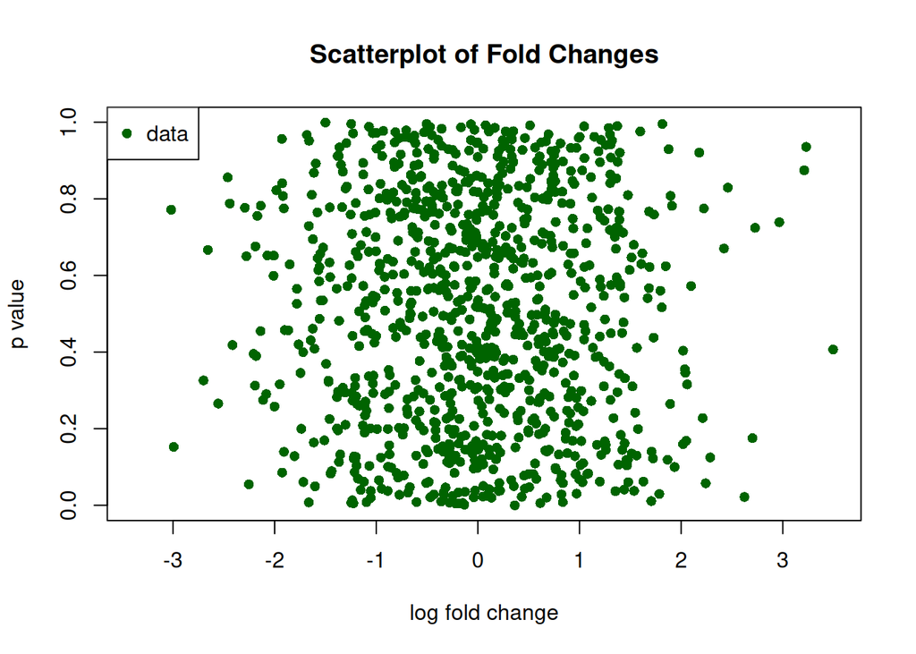

```r
plot(df$log2FC, df$p_value
     ,main = "Scatterplot of Fold Changes"
     ,type = "p" #for points
     ,xlab = "log fold change"
     ,ylab = "p value"
     ,col = "darkgreen"
     ,pch = 16 #filled circle
     )

# add legend
legend("topleft", c("data"), col = "darkgreen", pch=16)
```

### Histogram function

This function is useful to plot histograms.

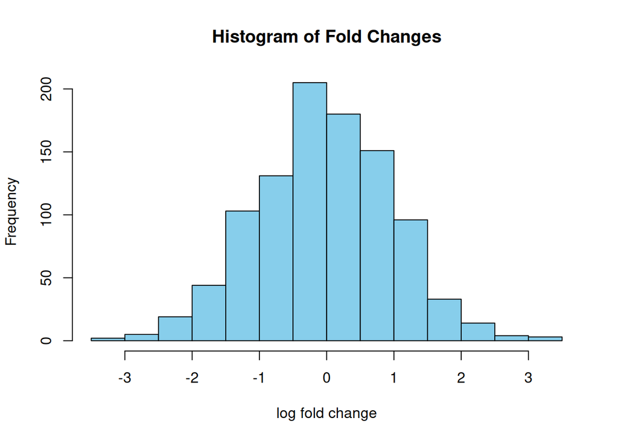

```r
# Plot histogram of fold changes
hist(df$log2FC,
     ,breaks = 10
     ,main = "Histogram of Fold Changes"
     ,xlab = "log fold change"
     ,col = "skyblue" #color
     )
```

### Boxplot function

Boxplots are often used to visualise the distribution of numeric values between categories.

In base R, boxplot uses the so-called formula notation expressed by the tilde `~` operator. You will also encounter this notation in linear models, for example. In our case, it will have the form of `value ~ category` such as:

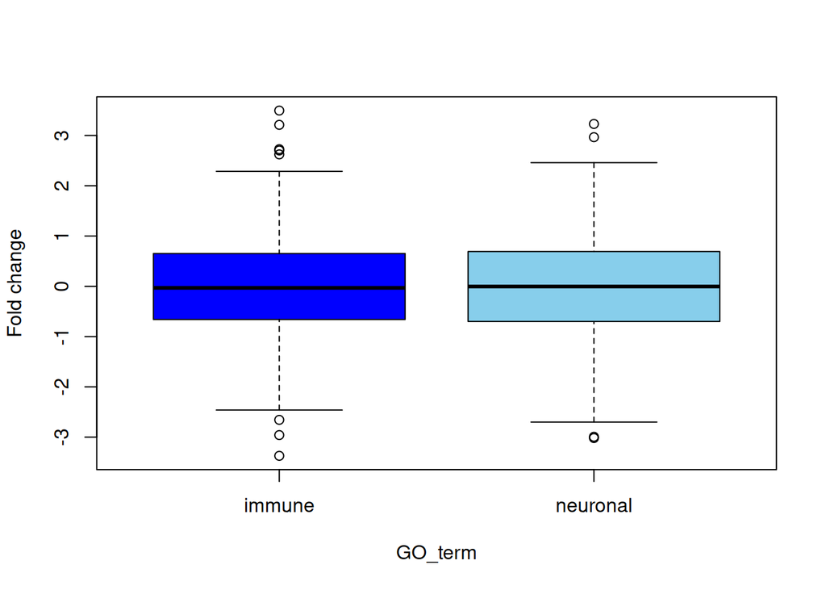

```r
# plot a boxplot - group by categorical variable (for example, GO term)

boxplot(log2FC ~ GO_term
        , data = df
        , ylab = "Fold change"
        , col = c("blue","skyblue")
        )
```

### Saving plots

In R there are graphic devices which handle the graphics and provide base functions to save plots: `pdf()` and `png()`.

```r
# here example with pdf, same with png
# use ?pdf() to see options on image size, etc.

# open the file to write to
pdf("figure1.pdf")
# produce the plot
boxplot(log2FC ~ GO_term
        , data = df
        , ylab = "Fold change"
        , col = c("blue","skyblue")
        )
# close the file
dev.off()
```

### Control flow

Control flow in programming allows you to execute commands based on a condition (`if` and `while` loops) and also to execute the same command on each element of many (`for` loops and `apply` functions).

#### Conditions

Conditions have a form of:

```
if (condition) {
  perform action
}
```

If a condition evaluates to `TRUE`, the command under `if` is executed, otherwise it is not, or a different command (under `else`) is executed, if provided.

```r
# Simple example of an if-else condition statements
# Try changing the value of x and see what happens
x <- 5
if (x == 5) {
  print("Correct!")
} else {
  print("Wrong!")
}
```

```
## [1] "Correct!"
```

#### Loops

Loops allow you to write a command once instead of repeating it for each element you want to execute it on. A simple loop in R has a form of:

```
for (element in vector) {
  perform action (element)
}
```

```r
#  for example, we take a squre root (built-in sqrt() function)
# from the grade from our students dataframe
for(gene in c("Gene_10", "Gene_100")){
  print(df[gene, ])
}
```

```
##             log2FC   p_value GO_term
## Gene_10 -0.0627141 0.3637062  immune
##             log2FC   p_value GO_term
## Gene_100 0.6532043 0.4966992  immune
```

Often, `for` loops in base R are replaced by a family of `apply` functions. The generic `apply` function has a form of `apply(X, MARGIN, FUNCTION)` where X is the data structure (can also be a matrix or array), MARGIN specifies dimensions to which we want to apply the FUNCTION (for example, 1 means rows, 2 means columns if X is a matrix). The syntax of `apply` is not very intuitive, but we can practice one often used `lapply(X, FUN)` function which performs operation on all elements of a vector or a list:

```r
# lapply applies function to a vector/list
# lapply always returns a list
lapply(c("Gene_10", "Gene_100"), toupper)
```

```
## [[1]]
## [1] "GENE_10"
##
## [[2]]
## [1] "GENE_100"
```

Some more information on the `apply` family and many examples can be found [here](https://rpubs.com/Richard_h/888425).

#### Anonymous functions

If there is no existing function to use in apply, you can create a function directly on the spot (this is sometimes called anonymous function). This function is not assigned to any name and only exists during the call. The syntax for anonymous function can be written fully `function(x) { do_something with x}` or shortened to `\(x) do_something with x`, for example `\(x) x+1` will add 1 to its argument. Instead of `x` you can use any name for the argument of the anonymous function (often a dot `.` is used).

```r
logplus <- lapply(df$log2FC, function(x) x+1)
logplus[1:5]
```

```
## [[1]]
## [1] 2.370958
##
## [[2]]
## [1] 0.4353018
##
## [[3]]
## [1] 1.363128
##
## [[4]]
## [1] 1.632863
##
## [[5]]
## [1] 1.404268
```

#### Vectorized operations

Vectorized functions in R can perform operations on all elements of a vector at the same time, avoiding use of `for` loop and `apply`. Those are very effective, and if possible, it is better to use them instead of loops. Many built-in R functions such as arithmetic operators, `log()` and similar perform vectorized operations if given vectors as arguments.

```r
# Vectorized function returns a vector
exp(df$log2FC[1:5])
```

```
## [1] 3.9391243 0.5685317 1.4378205 1.8829931 1.4982059
```

#### Vectorized conditions

`ifelse()` is a vectorized form of `if` if you provide a a vector of mixed `TRUE` and `FALSE` as a condition. It has a form of `ifelse(condition_vector, action1, action2)`, where action1 is performed if the condition in `TRUE` and action2 if the condition is `FALSE`.

```r
ifelse(df$p_value < 0.02, "significant", "not significant")[1:5]
```

```
## [1] "not significant" "not significant" "significant"     "not significant"
## [5] "not significant"
```

#### Pipe

Pipe is an operator to direct a variable or a result of a statement into a next statement, allowing to chain several statements after each other. The pipe of the form `%>%` comes with the `tidyverse` package, however, base R has a built-in pipe of the form `|>` (since R 4.0). Mainly the pipe serves to make your code more readable and allows to better break it over several lines:

```r
# instead of nesting functions like log(sum(sqrt(df$log2FC))), you can write:
df$log2FC |>
  sqrt() |>
  sum() |>
  log()
```

```
## [1] NaN
```

Base pipe always has to redirect to a function, and the name of the function has to be followed by brackets. If an anonymous function is used, the whole expression has to be put into brackets again, which makes the syntax (honestly) unreadable.

Luckily, you will learn tidyverse pipe operator `%>%` in the next class which handles it much better.

```r
# Anonymous function has to be put into brackets, followed by another brackets to signify it is a function
logplus1 <- df$log2FC |> (\(.) . + 1)()
logplus1[1:5]
```

```
## [1] 2.3709584 0.4353018 1.3631284 1.6328626 1.4042683
```

*Sources*

- Operators tables: [w3schools](https://www.w3schools.com/r/r_operators.asp)